# 20201107-p8133_probset11_jsg2145

Jared Garfinkel

11/7/2020

# Problem 11

## Part a

The first patient receives 1 of 2 potential treatments with equal probability.

p(A) = p(B) = 0.5

$p(tr = A|tr_{i-1} = A) = 0.2$

$p(tr = B|tr_{i-1} = B) = 0.8$

From this, the distribution of the first 4 patients can be calculated:

AAAA = 0.5 * 0.2 * 0.2 * 0.2 = 0.004 AAAB = 0.5 * 0.2 * 0.2 * 0.8 = 0.016 AABA = 0.5 * 0.2 * 0.8 * 0.2 = 0.016 ABAA = 0.5 * 0.8 * 0.2 * 0.2 = 0.016 BAAA = 0.5 * 0.2 * 0.2 * 0.2 = 0.004 AABB = 0.5 * 0.2 * 0.8 * 0.8 = 0.064 ABBA = 0.5 * 0.8 * 0.8 * 0.2 = 0.064 BBAA = 0.5 * 0.8 * 0.2 * 0.2 = 0.016 ABBB = 0.5 * 0.8 * 0.8 * 0.8 = 0.256 BBBA = 0.5 * 0.8 * 0.8 * 0.2 = 0.064 BBBB = 0.5 * 0.8 * 0.8 * 0.8 = 0.256 BBAB = 0.5 * 0.8 * 0.2 * 0.8 = 0.064 BABB = 0.5 * 0.2 * 0.8 * 0.8 = 0.064 BAAB = 0.5 * 0.2 * 0.2 * 0.8 = 0.016 BABA = 0.5 * 0.2 * 0.8 * 0.2 = 0.016 ABAB = 0.5 * 0.8 * 0.2 * 0.8 = 0.064

P(B = 0) = 0.004 P(B = 1) = 0.016 + 0.016 + 0.016 + 0.004 = .052 P(B = 2) = 0.064 + 0.064 + 0.016 + 0.016 + 0.016 + 0.064 = 0.24 P(B = 3) = 0.256 + 0.064 + 0.064 + 0.064 = .448 P(B = 4) = 0.256

0.004 + 0.052 + .24 + .256 + .448 = 1

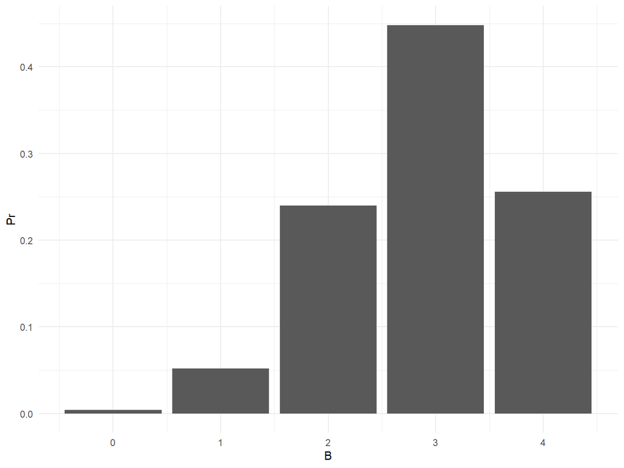

```r
tibble(B = c(0:4),
       Pr = c(.004,0.052,0.24,0.448,0.256)) %>%
  ggplot(aes(x = B, y = Pr)) +
  geom_bar(stat = "identity")
```

E[B] = 0 * 0.004 + 1 * 0.052 + 2 * 0.24 + 3 * 0.448 + 4 * 0.256 = 2.9

A balanced design would have 2 patients in each treatment group compared to an average of 2.9 in Zelen’s play-the-winner design.

## Part b

AAAA = 0.5 * 0.3 * 0.3 * 0.3 = 0.0135 AAAB = 0.5 * 0.3 * 0.3 * 0.7 = 0.0315 AABA = 0.5 * 0.3 * 0.7 * 0.7 = 0.0735 ABAA = 0.5 * 0.7 * 0.7 * 0.3 = 0.0735 BAAA = 0.5 * 0.7 * 0.3 * 0.3 = 0.0315 AABB = 0.5 * 0.3 * 0.7 * 0.3 = 0.0315 ABBA = 0.5 * 0.7 * 0.3 * 0.7 = 0.0735 BBAA = 0.5 * 0.3 * 0.7 * 0.3 = 0.0315 ABBB = 0.5 * 0.7 * 0.3 * 0.3 = 0.0315 BBBA = 0.5 * 0.3 * 0.3 * 0.7 = 0.0315 BBBB = 0.5 * 0.3 * 0.3 * 0.3 = 0.0135 BBAB = 0.5 * 0.3 * 0.7 * 0.7 = 0.0735 BABB = 0.5 * 0.7 * 0.7 * 0.3 = 0.0735 BAAB = 0.5 * 0.7 * 0.3 * 0.7 = 0.0735 BABA = 0.5 * 0.7 * 0.7 * 0.7 = 0.1715 ABAB = 0.5 * 0.7 * 0.7 * 0.7 = 0.1715

P(B = 0) = 0.0135 P(B = 1) = 0.0315 + 0.0735 + 0.0735 + 0.0315 = 0.21 P(B = 2) = 0.0315 + .0735 + 0.0315 + 0.0735 + 0.1715 + 0.1715 = .553 P(B = 3) = 0.0315 + 0.0315 + 0.0735 + 0.0735 = 0.21 P(B = 4) = 0.0135

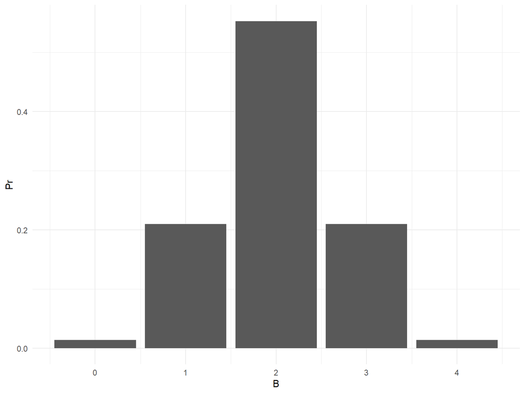

```r
tibble(B = c(0:4),
       Pr = c(0.0135,0.21,0.553,0.21,0.0135)) %>%
  ggplot(aes(x = B, y = Pr)) +
  geom_bar(stat = "identity")
```

E[B] = 0 * 0.0135 + 1 * 0.21 + 2 * 0.553 + 3 * 0.21 + 4 * 0.0135 = 2

When both treatments have a probability of response of 0.3 the expected value of the distribution of B is the same as the balanced design.